# RP Differential Analysis All Isolates+Seeds All

# 1. Importing Libraries

```r
library(tidyverse)
library(ggrepel)
library(ggsci)
library(pheatmap)
library(RColorBrewer)
library(readxl)
library(UpSetR)
source('functions_cdis_diff.R')
```

Change to what data you are using

```r
data= 'RP'
```

# 2. Import data

Because differential analysis includes the calculations of means, the data to be used in this section is the normalized untransformed data

```r
# set path variables
project_dir <- getwd()
project_name <- 'RP_All_1154'
figures_dir <- file.path(project_dir, paste0(project_name, '_output_figures'))
tables_dir <- file.path(project_dir,  paste0(project_name, '_output_tables'))
norm_auc_table_file <- file.path(tables_dir, 'normalized_untransformed_auc_table.csv')
norm_auc_table_nogap_file <- file.path(tables_dir, 'normalized_untransformed_auc_table_nogap.csv')
# If the flag was setted before, nothing needs to be changed here, the correct file will be automatically used

  compounds_table_file <- file.path(tables_dir, 'compounds_table.csv')


# Load auc_table

norm.matrix <- read_csv(norm_auc_table_nogap_file)
norm.matrix <- column_to_rownames(norm.matrix, var = '...1')

norm.matrix_nogap <- read_csv(norm_auc_table_nogap_file)
norm.matrix_nogap <- column_to_rownames(norm.matrix_nogap, var = '...1')

# Load compounds table and add a column that has names for identified compounds and FeatureID for the rest (for plotting puRPouses)

compounds_table <- read_csv(compounds_table_file)

# Import metadata and fix names
metadata_file <- file.path(tables_dir, 'fixed_metadata.csv')
metadata <- read_csv(metadata_file)
```

# 3. Calculate ratios and log2fold-change

## 3.1 Get samples per each treatment

```r
# Get the average AUC per each of the treatments
## Get samples per treatment

ERLE.samples <- get_samples(metadata, Treatment = 'Plant', value = 'ERLE')
ERIN.samples <- get_samples(metadata, Treatment = 'Plant', value = 'ERIN')
BOCU.samples <- get_samples(metadata, Treatment = 'Plant', value = 'BOCU')
LEDU.samples <- get_samples(metadata, Treatment = 'Plant', value = 'LEDU')
CTRL.samples <- get_samples(metadata, Treatment = 'Fungi', value = 'CTRL')
```

## 3.2 Get table of differentially expressed features per each comparison

The following function will calculate ratio, log2FC, p values and adjusted pvalues. If no replicates are available for EACH treatment please use the get_diff_table_no_pval() function

```r
# The following function will calculate ratio, log2FC, p values and adjusted pvalues. If no replicates are available for EACH treatment
# please use the get_diff_table_no_pval() function

ERLE_to_CTRL.diff_table <- get_diff_table(norm.matrix, treatment.sample_list = ERLE.samples, control.sample_list = CTRL.samples, log2_transformed = TRUE)
ERIN_to_CTRL.diff_table <- get_diff_table(norm.matrix, treatment.sample_list = ERIN.samples, control.sample_list = CTRL.samples, log2_transformed = TRUE)
BOCU_to_CTRL.diff_table <- get_diff_table(norm.matrix, treatment.sample_list = BOCU.samples, control.sample_list = CTRL.samples, log2_transformed = TRUE)
LEDU_to_CTRL.diff_table <- get_diff_table(norm.matrix, treatment.sample_list = LEDU.samples, control.sample_list = CTRL.samples, log2_transformed = TRUE)
```

Merge differentially expressed features with the annotation

```r
# Create dataframes for the up and downregulated metabolites at each time point and merge them with the compound information

ERLE_to_CTRL.diff_table <- compounds_table %>%
  select( - contains('Results'), -SampleID, -AUC,  -Fungi, - Plant) %>%
  right_join(ERLE_to_CTRL.diff_table, by = 'FeatureID') %>%
  distinct() %>%
  filter(!is.nan(log2FC)) %>%
  mutate(Comment = case_when(log2FC < 0 ~ 'Downregulated',
                             log2FC > 0 ~ 'Upregulated'))

ERLE_to_CTRL.diff_table$Comment <- factor(ERLE_to_CTRL.diff_table$Comment,
                               levels = c( 'Downregulated', 'Upregulated' ))

table_file <- file.path(tables_dir, 'Diff_expressed_ERLE.csv')
write_csv(ERLE_to_CTRL.diff_table, table_file )

ERIN_to_CTRL.diff_table<- compounds_table %>%
  select(-contains('Annotation Source:'), - contains('Results'), -SampleID, -AUC, -Plant, - Fungi) %>%
  right_join(ERIN_to_CTRL.diff_table, by = 'FeatureID') %>%
  distinct() %>%
  filter(!is.nan(log2FC)) %>%
  mutate(Comment = case_when(log2FC < 0 ~ 'Downregulated',
                             log2FC > 0 ~ 'Upregulated'))

ERIN_to_CTRL.diff_table$Comment <- factor(ERIN_to_CTRL.diff_table$Comment,
                               levels = c( 'Downregulated', 'Upregulated'))

table_file <- file.path(tables_dir, 'Diff_expressed_ERIN.csv')
write_csv(ERIN_to_CTRL.diff_table, table_file )

BOCU_to_CTRL.diff_table <- compounds_table %>%
  select(-contains('Annotation Source:'), - contains('Results'), -SampleID, -AUC, -Plant, -Fungi) %>%
  right_join(BOCU_to_CTRL.diff_table, by = 'FeatureID') %>%
  distinct() %>%
  filter(!is.nan(log2FC)) %>%
  mutate(Comment = case_when(log2FC < 0 ~ 'Downregulated',
                             log2FC > 0 ~ 'Upregulated'))

BOCU_to_CTRL.diff_table$Comment <- factor(BOCU_to_CTRL.diff_table$Comment,
                               levels = c('Downregulated', 'Upregulated' ))

table_file <- file.path(tables_dir, 'Diff_expressed_BOCU.csv')
write_csv(BOCU_to_CTRL.diff_table, table_file )

LEDU_to_CTRL.diff_table <- compounds_table %>%
  select(-contains('Annotation Source:'), - contains('Results'), -SampleID, -AUC, -Plant, -Fungi) %>%
  right_join(LEDU_to_CTRL.diff_table, by = 'FeatureID') %>%
  distinct() %>%
  filter(!is.nan(log2FC)) %>%
  mutate(Comment = case_when(log2FC < 0 ~ 'Downregulated',
                             log2FC > 0 ~ 'Upregulated'))

LEDU_to_CTRL.diff_table$Comment <- factor(LEDU_to_CTRL.diff_table$Comment,
                               levels = c('Downregulated', 'Upregulated' ))

table_file <- file.path(tables_dir, 'Diff_expressed_LEDU.csv')
write_csv(LEDU_to_CTRL.diff_table, table_file )
```

Extract most differentially expressed features

```r
# Extract significant features of each comparison based on adjusted pvalue
sig_features <- c(ERLE_to_CTRL.diff_table$FeatureID[ERLE_to_CTRL.diff_table$pval < 0.05],
                  ERIN_to_CTRL.diff_table$FeatureID[ERIN_to_CTRL.diff_table$pval < 0.05],
                  BOCU_to_CTRL.diff_table$FeatureID[BOCU_to_CTRL.diff_table$pval < 0.05],

LEDU_to_CTRL.diff_table$FeatureID[LEDU_to_CTRL.diff_table$pval < 0.05])

sig_features <- unique(sig_features)
```

# 4. Plots of dysregulated features

## 4.1 Number of dysregulated features in each group

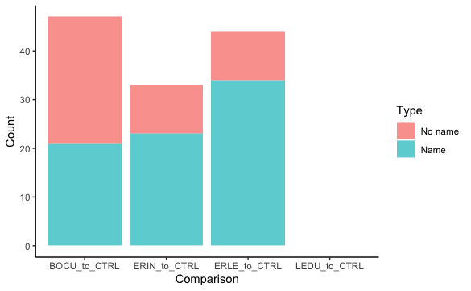

```r
# removed pval adj to regular pval
num_diff_features <- tibble(Comparison = rep(c('ERLE_to_CTRL', 'ERIN_to_CTRL', 'BOCU_to_CTRL', 'LEDU_to_CTRL'), each = 2),
                            Type = rep(c('Name', 'No name'), 4),
                            count = 0)
num_diff_features$Type <- factor(num_diff_features$Type, levels = c('No name', 'Name'))

num_diff_features[1, 3] <- sum(ERLE_to_CTRL.diff_table$pval < 0.05 & !is.na(ERLE_to_CTRL.diff_table$Name), na.rm = TRUE)
num_diff_features[2, 3] <- sum(ERLE_to_CTRL.diff_table$pval < 0.05 & is.na(ERLE_to_CTRL.diff_table$Name), na.rm = TRUE)
num_diff_features[3, 3] <- sum(ERIN_to_CTRL.diff_table$pval < 0.05 & !is.na(ERIN_to_CTRL.diff_table$Name), na.rm = TRUE)
num_diff_features[4, 3] <- sum(ERIN_to_CTRL.diff_table$pval< 0.05 & is.na(ERIN_to_CTRL.diff_table$Name), na.rm = TRUE)
num_diff_features[5, 3] <- sum(BOCU_to_CTRL.diff_table$pval < 0.05 & !is.na(BOCU_to_CTRL.diff_table$Name), na.rm = TRUE)
num_diff_features[6, 3] <- sum(BOCU_to_CTRL.diff_table$pval< 0.05 & is.na(BOCU_to_CTRL.diff_table$Name), na.rm = TRUE)
num_diff_features[5, 3] <- sum(LEDU_to_CTRL.diff_table$pval< 0.05 & !is.na(LEDU_to_CTRL.diff_table$Name), na.rm = TRUE)
num_diff_features[6, 3] <- sum(LEDU_to_CTRL.diff_table$pval < 0.05 & is.na(LEDU_to_CTRL.diff_table$Name), na.rm = TRUE)

num_diff_plot <- ggplot(num_diff_features)+
  geom_bar(aes(y=count, x=Comparison,fill= Type), stat="identity", alpha=0.7)+
  theme_classic()+xlab("Comparison")+ylab("Count")

num_diff_plot
# shows snumber of significantly regulated compounds
figure_file <- file.path(figures_dir, 'Num_diff_features.png')
ggsave(figure_file, num_diff_plot, dpi = 300)
```

## 4.2 Dysregulated features shared at different timepoints

An **upset plot**is used instead of a Venn Diagram as it provides a better visualization of the number of figures that are being shared among groups

```r
#Filter diff tables by pval.adj

ERLE.sig<-ERLE_to_CTRL.diff_table%>%
  filter(pval<0.05)
ERIN.sig<-ERIN_to_CTRL.diff_table%>%
  filter(pval<0.05)
BOCU.sig<-BOCU_to_CTRL.diff_table%>%
  filter(pval<0.05)
LEDU.sig<-LEDU_to_CTRL.diff_table%>%
  filter(pval<0.05)

#Get list of features at each time point for each of the cases
ERLE.upregulated<-get_vectors(ERLE.sig, 'Comment', 'Upregulated', 'FeatureID')
ERLE.downregulated<-get_vectors(ERLE.sig, 'Comment', 'Downregulated', 'FeatureID')
#ERLE.not_in_control<-get_vectors(ERLE.sig, 'Comment', 'Not #present in control', 'FeatureID')
#ERLE.only_in_control<-get_vectors(ERLE.sig, 'Comment', 'Only #present in control', 'FeatureID')

ERIN.upregulated<-get_vectors(ERIN.sig, 'Comment', 'Upregulated', 'FeatureID')
ERIN.downregulated<-get_vectors(ERIN.sig, 'Comment', 'Downregulated', 'FeatureID')
#ERIN.not_in_control<-get_vectors(ERIN.sig, 'Comment', 'Not present in control', 'FeatureID')
#ERIN.only_in_control<-get_vectors(ERIN.sig, 'Comment', 'Only present in control', 'FeatureID')

BOCU.upregulated<-get_vectors(BOCU.sig, 'Comment', 'Upregulated', 'FeatureID')
BOCU.downregulated<-get_vectors(BOCU.sig, 'Comment', 'Downregulated', 'FeatureID')
#BOCU.not_in_control<-get_vectors(BOCU.sig, 'Comment', 'Not present in control', 'FeatureID')
#BOCU.only_in_control<-get_vectors(BOCU.sig, 'Comment', 'Only present in control', 'FeatureID')

LEDU.upregulated<-get_vectors(LEDU.sig, 'Comment', 'Upregulated', 'FeatureID')
LEDU.downregulated<-get_vectors(LEDU.sig, 'Comment', 'Downregulated', 'FeatureID')
#LEDU.not_in_control<-get_vectors(LEDU.sig, 'Comment', 'Not present in control', 'FeatureID')
#LEDU.only_in_control<-get_vectors(LEDU.sig, 'Comment', 'Only present in control', 'FeatureID')
```

```r
upset_input<-list(ERLE.upregulated=ERLE.upregulated,
                    ERLE.downregulated=ERLE.downregulated,
                    #ERLE.not_in_control=ERLE.not_in_control,
                    #ERLE.only_in_control=ERLE.only_in_control,
                    ERIN.upregulated=ERIN.upregulated,
                    ERIN.downregulated=ERIN.downregulated,
                    #ERIN.not_in_control=ERIN.not_in_control,
                    #ERIN.only_in_control=ERIN.only_in_control,
                    BOCU.upregulated=BOCU.upregulated,
                    BOCU.downregulated=BOCU.downregulated,
                  LEDU.upregulated=LEDU.upregulated,
                  LEDU.downregulated=LEDU.downregulated)
                    #BOCU.not_in_control=BOCU.not_in_control,
                    #BOCU.only_in_control=BOCU.only_in_control)

upset_metadata<-data.frame(sets=as.vector(names(upset_input)),
                         Time=rep(c('ERLE', 'ERIN', 'BOCU', 'LEDU'), each=4))

upset_features<-upset(fromList(upset_input), order.by="freq", cutoff=1, nsets=12,
                    mainbar.y.label='Number of shared features', sets.x.label='Number of features',
                    text.scale=c(1.5, 1, 1.5, 1, 1.3, 1.3),
                    set.metadata=list(data=upset_metadata,
                                        plots=list(list(type='matrix_rows', column='Time',
                                                          colors=c(ERLE='#EFC000FF', ERIN='#868686FF', BOCU='#CD534CFF')))))
upset_features
```

```r
figure_file<-file.path(figures_dir, 'Upset-KEGG.png')
png(figure_file, width=800, height=800, res=100)
upset_features
```

[figure not shown]

```r
dev.off()
```

## 4.2 Volcano plots

labels if L2FC is doubble lfc.t

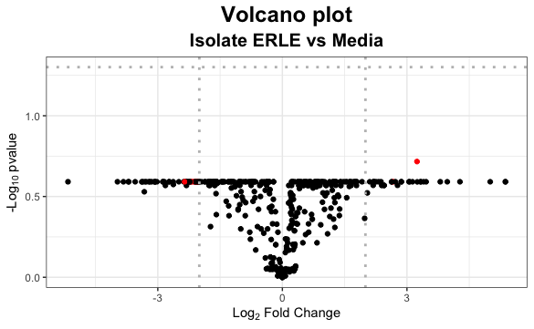

```r
lfc.t <- 2
pval.t <- 0.05

ERLE_to_CTRL_volcano <- plot_volcano(ERLE_to_CTRL.diff_table, log2FC, pval.adj, lfc.t, pval.t) +
  labs(subtitle = 'Isolate ERLE vs Media')
ERLE_to_CTRL_volcano

figure_file <- file.path(figures_dir, 'ERLE_CTRL_volcano.png')
ggsave(figure_file, ERLE_to_CTRL_volcano, width=20, height=20, unit='cm')
```

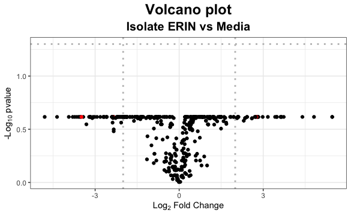

```r
ERIN_to_CTRL_volcano <- plot_volcano(ERIN_to_CTRL.diff_table, log2FC, pval.adj, lfc.t, pval.t) +
  labs(subtitle = 'Isolate ERIN vs Media')
ERIN_to_CTRL_volcano

figure_file <- file.path(figures_dir, 'ERIN_CTRL_volcano.png')
ggsave(figure_file, ERIN_to_CTRL_volcano, width=20, height=20, unit='cm')
```

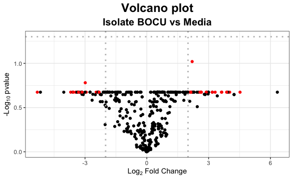

```r
BOCU_to_CTRL_volcano <- plot_volcano(BOCU_to_CTRL.diff_table, log2FC, pval.adj, lfc.t, pval.t) +
  labs(subtitle = 'Isolate BOCU vs Media')
BOCU_to_CTRL_volcano

figure_file <- file.path(figures_dir, 'BOCU_CTRL_volcano.png')
ggsave(figure_file, BOCU_to_CTRL_volcano, width=20, height=20, unit='cm')
```

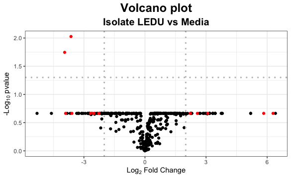

```r
LEDU_to_CTRL_volcano <- plot_volcano(LEDU_to_CTRL.diff_table, log2FC, pval.adj, lfc.t, pval.t) +
  labs(subtitle = 'Isolate LEDU vs Media')
LEDU_to_CTRL_volcano

figure_file <- file.path(figures_dir, 'LEDU_CTRL_volcano.png')
ggsave(figure_file, LEDU_to_CTRL_volcano, width=20, height=20, unit='cm')
```

```r
# Filter diff tables by pval.adj
BOCU.sig <- BOCU_to_CTRL.diff_table %>%
  filter(pval< 0.05)
ERLE.sig <- ERLE_to_CTRL.diff_table %>%
  filter(pval < 0.05)
ERIN.sig <- ERIN_to_CTRL.diff_table %>%
  filter(pval < 0.05)
LEDU.sig<-LEDU_to_CTRL.diff_table%>%
  filter(pval<0.5)

BOCU.sig2 <- BOCU.sig %>%
  filter(log2FC > 2 | log2FC < 0.5)
ERLE.sig2 <- ERLE.sig %>%
  filter(log2FC > 2 | log2FC < 0.5)
ERIN.sig2 <- ERIN.sig %>%
  filter(log2FC > 2 | log2FC < 0.5)
LEDU.sig2 <- LEDU.sig %>%
  filter(log2FC > 2 | log2FC < 0.5)

ERLE.sig2$isolate<- "ERLE"
ERIN.sig2$isolate<- "ERIN"
BOCU.sig2$isolate<- "BOCU"
LEDU.sig2$isolate<-"LEDU"
sig.all<- rbind(ERLE.sig2, ERIN.sig2, BOCU.sig2, LEDU.sig2)

table_file <- file.path(tables_dir, 'Sig.diff.expressed.allIsolates_L2FC_0.3.csv')
write_csv(sig.all, table_file )
# Get list of features at each time point for each of the cases
BOCU.upregulated <- get_vectors(BOCU.sig, 'Comment', 'Upregulated', 'FeatureID')
BOCU.downregulated <- get_vectors(BOCU.sig, 'Comment', 'Downregulated', 'FeatureID')
#BOCU.not_in_control <- get_vectors(BOCU.sig, 'Comment', 'Not present in control', 'FeatureID')
#BOCU.only_in_control <- get_vectors(BOCU.sig, 'Comment', 'Only present in control', 'FeatureID')
ERLE.upregulated <- get_vectors(ERLE.sig, 'Comment', 'Upregulated', 'FeatureID')
ERLE.downregulated <- get_vectors(ERLE.sig, 'Comment', 'Downregulated', 'FeatureID')
#ERLE.not_in_control <- get_vectors(ERLE.sig, 'Comment', 'Not present in control', 'FeatureID')
#ERLE.only_in_control <- get_vectors(ERLE.sig, 'Comment', 'Only present in control', 'FeatureID')
ERIN.upregulated <- get_vectors(ERIN.sig, 'Comment', 'Upregulated', 'FeatureID')
ERIN.downregulated <- get_vectors(ERIN.sig, 'Comment', 'Downregulated', 'FeatureID')
#ERIN.not_in_control <- get_vectors(ERIN.sig, 'Comment', 'Not present in control', 'FeatureID')
#ERIN.only_in_control <- get_vectors(ERIN.sig, 'Comment', 'Only present in control', 'FeatureID')
```

## 4.3 Van Krevelen Diagrams of dysregulated features

**Dysregulated features at ERLE**

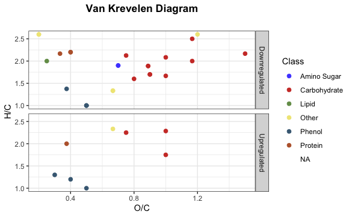

```r
ERLE_vank<-plot_vank(ERLE.sig, Class, Comment)
ERLE_vank

figure_file<-file.path(figures_dir, 'DE_vank_ERLE.png')
ggsave(figure_file, ERLE_vank)
```

**Dysregulated features at ERIN*

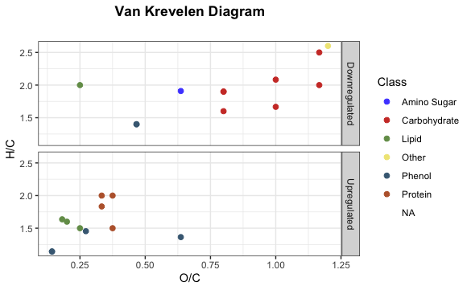

```r
ERIN_vank<-plot_vank(ERIN.sig, Class, Comment)
ERIN_vank

figure_file<-file.path(figures_dir, 'DE_vank_ERIN.png')
ggsave(figure_file, ERIN_vank)
```

**Dysregulated features at BOCU**

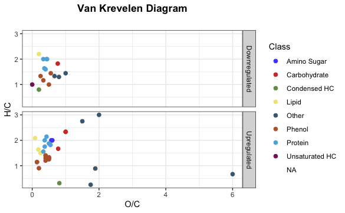

```r
BOCU_vank<-plot_vank(BOCU.sig, Class, Comment)
BOCU_vank

figure_file<-file.path(figures_dir, 'DE_vank_BOCU.png')
ggsave(figure_file, BOCU_vank)
```

Van Krevelen of all

```r
sig_all<-rbind(ERLE.sig%>% select(FeatureID, Comment) %>% mutate(Fungi='1154'),
                 ERIN.sig%>% select(FeatureID, Comment) %>% mutate(Fungi='1177'),
                 BOCU.sig%>% select(FeatureID, Comment) %>% mutate(Fungi='1246'))

sig_all_compounds_table<-compounds_table%>%
  select(FeatureID, H_to_C, O_to_C, Class, Fungi, GFE, Plant) %>%
  distinct() %>%
  left_join(sig_all, by=c('FeatureID', 'Fungi'))%>%
  na.omit()



my_colors=c('Upregulated'='tomato2',
              'Downregulated'='lightsteelblue')



dysreg_vk<-ggplot(sig_all_compounds_table,
                    aes(x=O_to_C,
                        y=H_to_C,
                        color=Class)) +
  geom_point() +
  scale_color_manual(values=my_colors) +
  theme_classic() +
  labs(x='O:C',
       y='H:C',
       title='Van Krevelen Diagram ',
       color='Assigned compound class') +
  #new_scale_color() +
  #class_rect+
  scale_color_manual(values=get_palette('d3', 8)) +
  theme(plot.title=element_text(face='bold', hjust=0.5)) +
  facet_wrap(~Fungi*Comment, 3)
```

[output not shown]

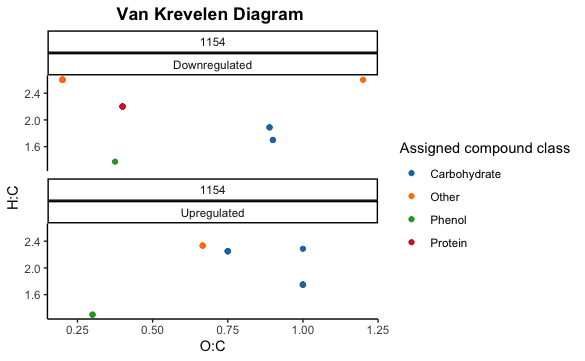

```r
dysreg_vk

figure_file<-file.path(figures_dir, 'dysreg_vk.png')
ggsave(figure_file, dysreg_vk)
```

## 4.4 GFE plots of dysregulated features

**Dysregulated features at ERLE**

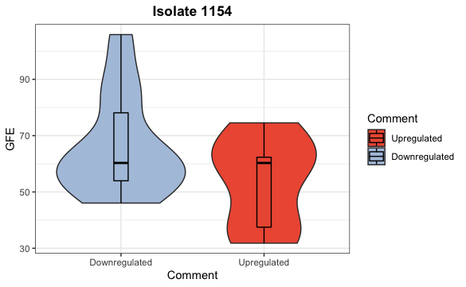

```r
my_colors=c(
              'Upregulated'='tomato2',
              'Downregulated'='lightsteelblue')

ERLE_GFE_box<-plot_boxplot(ERLE.sig, Comment, GFE, Comment, my_colors)+ labs(title='Isolate 1154')
ERLE_GFE_box

figure_file<-file.path(figures_dir, 'DE_GFE_ERLE.png')
ggsave(figure_file, ERLE_GFE_box)
```

**Dysregulated features at ERIN**

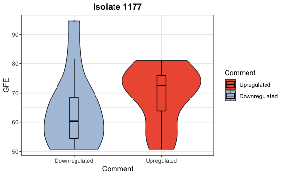

```r
ERIN_GFE_box<-plot_boxplot(ERIN.sig, Comment, GFE, Comment, my_colors)+ labs(title='Isolate 1177')
ERIN_GFE_box

figure_file<-file.path(figures_dir, 'DE_GFE_ERIN.png')
ggsave(figure_file, ERIN_GFE_box)
```

**Dysregulated features at BOCU**

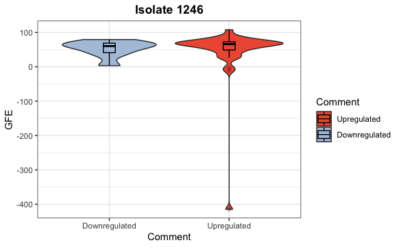

```r
BOCU_GFE_box<-plot_boxplot(BOCU.sig, Comment, GFE, Comment, my_colors)+ labs(title= 'Isolate 1246')
BOCU_GFE_box

figure_file<-file.path(figures_dir, 'DE_GFE_BOCU.png')
ggsave(figure_file, BOCU_GFE_box)
```

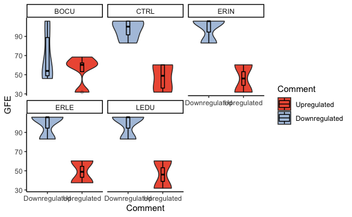

```r
all_GFE_box<- ggplot(sig_all_compounds_table,
         aes(x = Comment,
             y = GFE,
             fill = Comment)) +
    geom_violin() +
    geom_boxplot(width=0.1, color="black", alpha=0.2) +
    scale_fill_manual(values = my_colors) +
    theme_classic() +
    theme(plot.title = element_text(face = 'bold', hjust = 0.5))+
  facet_wrap(~Plant)
all_GFE_box
figure_file<-file.path(figures_dir, 'all_GFE.png')
ggsave(figure_file, all_GFE_box)
```

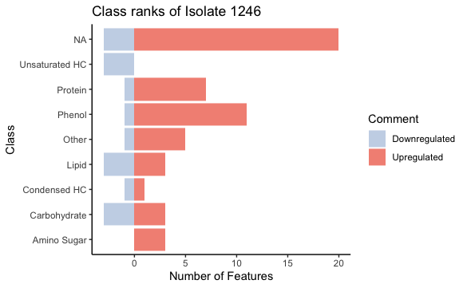

```r
BOCU.count<- BOCU.sig%>% #BOCU.sig only includes sig. up/down regulated features
    select(FeatureID, Class, Comment, pval.adj)%>%
    count(Class, Comment)

BOCU.count <- within(BOCU.count, n[Comment=="Downregulated"] <- (n*(-1))) #Makes downregulated features negative in the figure
class.plot<- ggplot(BOCU.count)+
geom_bar(aes(y=Class, x=n,fill= Comment), stat="identity", alpha=0.7)+
   scale_fill_manual(values = c("lightsteelblue","tomato2"))+
  theme_classic()+xlab("Number of Features")+ylab("Class")+
  labs(title="Class ranks of Isolate 1246")
class.plot

figure_file <- file.path(figures_dir, 'Class_rank_BOCU.png')
ggsave(figure_file, class.plot, width=15, height=10, unit='cm')
```

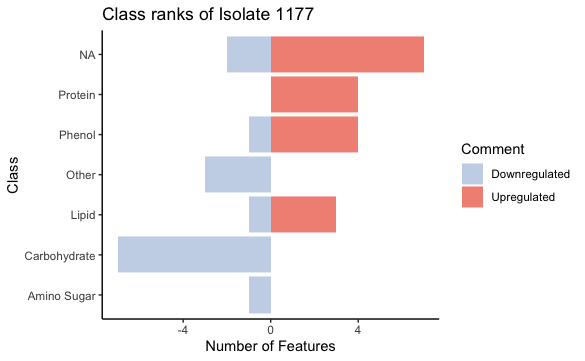

```r
# I then repeated theses scripts for each isolate


ERIN.count<- ERIN.sig%>%
    select(FeatureID, Class, Comment, pval.adj)%>%
    count(Class, Comment)
ERIN.count <- within(ERIN.count, n[Comment=="Downregulated"] <- (n*(-1)))
    #filter(Comment != "Only present in control")

class.plot<- ggplot(ERIN.count)+
geom_bar(aes(y=Class, x=n,fill= Comment), stat="identity", alpha=0.7)+
   scale_fill_manual(values = c("lightsteelblue","tomato2"))+
  theme_classic()+xlab("Number of Features")+ylab("Class")+
  labs(title="Class ranks of Isolate 1177")
class.plot

figure_file <- file.path(figures_dir, 'Class_rank_ERIN.png')
ggsave(figure_file, class.plot, width=15, height=10, unit='cm')
```

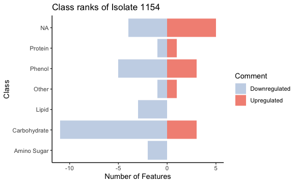

```r
ERLE.count<- ERLE.sig%>%
    select(FeatureID, Class, Comment, pval.adj, pval)%>%
    count(Class, Comment)
ERLE.count <- within(ERLE.count, n[Comment=="Downregulated"] <- (n*(-1)))
    #filter(Comment != "Only present in control")

class.plot<- ggplot(ERLE.count)+
geom_bar(aes(y=Class, x=n,fill= Comment), stat="identity", alpha=0.7)+
   scale_fill_manual(values = c("lightsteelblue","tomato2"))+
  theme_classic()+xlab("Number of Features")+ylab("Class")+
  labs(title="Class ranks of Isolate 1154")
class.plot

figure_file <- file.path(figures_dir, 'Class_rank_ERLE.png')
ggsave(figure_file, class.plot, width=15, height=10, unit='cm')
```

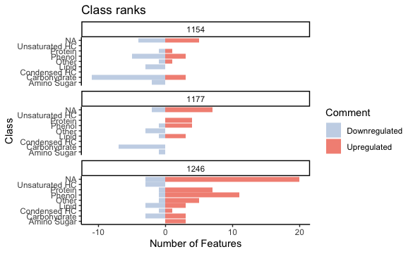

```r
ERLE.count$isolate<- 1154
ERIN.count$isolate<- 1177
BOCU.count$isolate<- 1246
class.rank.all<- rbind(ERLE.count, ERIN.count, BOCU.count)


class.plot<- ggplot(class.rank.all)+
geom_bar(aes(y=Class, x=n,fill= Comment), stat="identity", alpha=0.7)+
  facet_wrap(~isolate, 3)+
   scale_fill_manual(values = c("lightsteelblue","tomato2"))+
  theme_classic()+xlab("Number of Features")+ylab("Class")+
  labs(title="Class ranks")
class.plot

figure_file <- file.path(figures_dir, 'Class_rank_all.png')
ggsave(figure_file, class.plot, width=15, height=10, unit='cm')
```

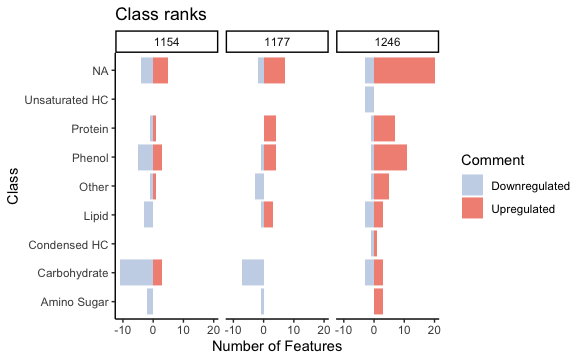

```r
class.plot<- ggplot(class.rank.all)+
geom_bar(aes(y=Class, x=n,fill= Comment), stat="identity", alpha=0.7)+
  facet_wrap(~isolate, 1)+
   scale_fill_manual(values = c("lightsteelblue","tomato2"))+
  theme_classic()+xlab("Number of Features")+ylab("Class")+
  labs(title="Class ranks")
class.plot

figure_file <- file.path(figures_dir, 'Class_rank_all_2.png')
ggsave(figure_file, class.plot, width=15, height=10, unit='cm')
```

```r
NA
NA
NA
```